# Review of Air Quality App Usage

David Hall

2021-11-14

# Background

The CHM135 [Air Quality App](https://davidrosshall.shinyapps.io/AirQualityApp/) has been used for during the Winter 2021 and Fall 2021 iterations of the virtual CHM135 labs. The **Winter 2021 term has ~200 students** enrolled across seven sections. The **Fall 2021 term has ~2300 students** enrolled across a lot of sections (unsure of number of sections). This document is just me combing through the sparse Shiny App metrics for an understanding of app usage, etc.

# Results and Discussion

There isn’t much recorded by the Shiny server in terms of user metrics. The metrics that are recorded relate to server usage rather than user experience. Nonetheless, we can glean some interesting insights.

## Number of App Connections

The Shiny server records the number of connections to the app. Note that there can be multiple connections for a given individual (i.e. they go to the website on two different days). Nonetheless, it provides a useful approximate for the number of people who’ve used the app. Figure 1 shows the daily connections to the app, and the cummulative connections over the Exp. 1 sessions for both the Winter and Fall 2021 terms. Predictably, the most connection are towards the tail end of the *Practical 1* synchronous sessions, with particular spiking occuring in the hours leading up to a particular sessions deadline.

There were two reported isntances of the app crashing during the Fall 2021 session. The app didn’t “crash”, rather the settings at the time limited the number of connections at one point, meaning that once that number of connections was reached, the app wouldn’t connect for the next user. So in the first instance on Sept 29 there was room for 100 concurrent connections, which was exceeded. The app was expanded to allow for 250 connections and reset, but this new limit was reached on October 4th. The app was reset to allow *250 connections for each of four worker processes* for a total of 1000 allowable connections.

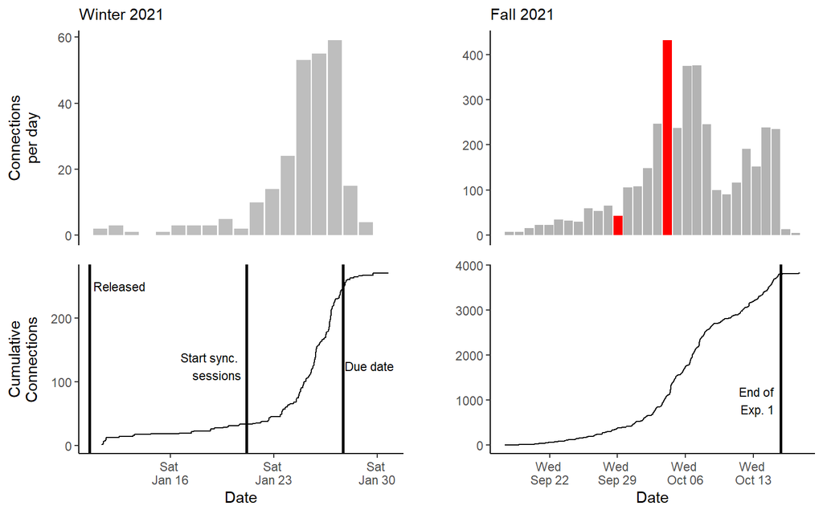

Connections to Air Quality app per day (top) and cummulative connections over time (bottom) for the Winter and Fall 2021 sessions. Red bars denote days when the app crashed and required resetting and expansion of number of allowable connections. Note discrepency of y-axis between Winter and Fall 2021 sessions.

## Acitve hours

Active hours are isntanced where the app is up, running, and serving requests, whether it’s one user or one hundred. This is the primary metric from which the Shiny server billing covers. The *Standard* plan, purchased for both the Winter and Fall 2021 sessions for $99 USD/month, includes 2000 active hours. For the Fall 2021 session we used 449.31 hours.

Active app hours per day. App hours are instances where the app is running and serving request, wherether it’s 1 user or 100.

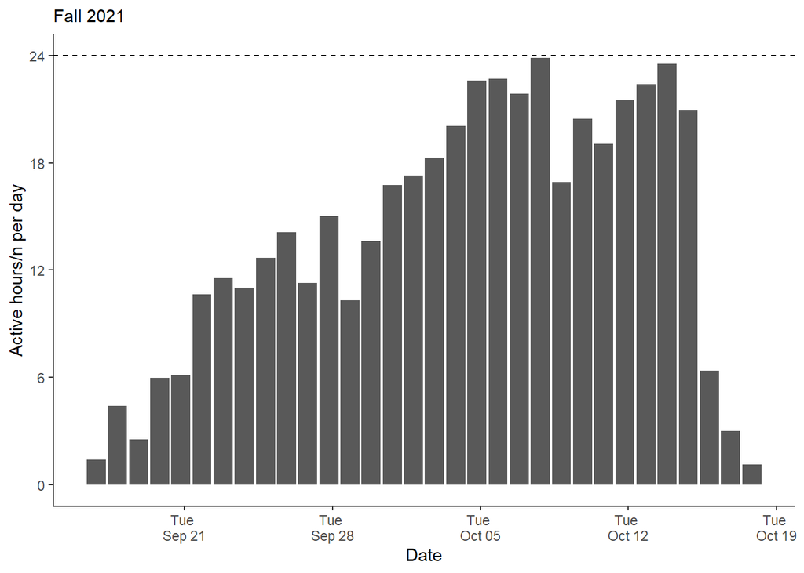

## App memory

Another consideration for the app is the memory required for the server. The ECCC2018 data loaded into the app, and from which all the plots are derived, is only 10.1665526 MB large. After two crashes, I upgraded the memory on the server to 8 GB, which appears to have been overkill all things considering. Note this memory serves all the workers.

App memory usage during the Fall 2021 session. Red bars denote days when the app crashed and required resetting and expansion of number of allowable connections.

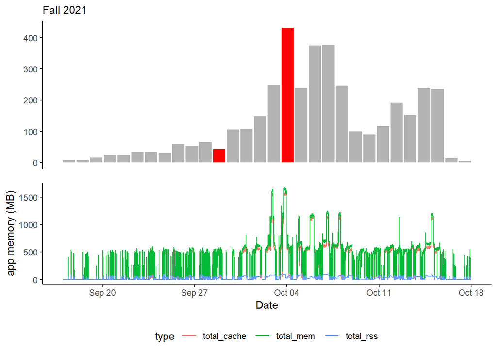